# Animal Disease Outbreaks

## OPTICS with PCA Components for All Features

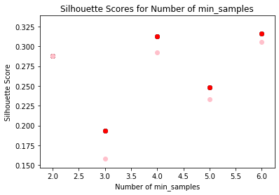

[output not shown]

```python
# With PCA components from features with greater than 0.01 correlation

pca = PCA(n_components=2)
pca_components = pca.fit_transform(X_all)
silhouettes_optics_pca = []
min_samples = [2, 3, 4, 5, 6]
dbs_optics_pca = []

# looping through cluster numbers to find the best cluster
silhouettes_optics_pca_auto = {} # silhoutte scores are keys, n_components are values
for n in min_samples:
        optics_cluster = OPTICS(min_samples=n, algorithm='auto')
        cluster_labels = optics_cluster.fit_predict(pca_components)
        silhouette = metrics.silhouette_score(pca_components, cluster_labels, metric='euclidean')
        silhouettes_optics_pca_auto[silhouette] = n
        db = metrics.davies_bouldin_score(pca_components, cluster_labels)
        dbs_optics_pca.append(db)

silhouettes_optics_pca_ball_tree = {} # silhoutte scores are keys, n_components are values
for n in min_samples:
        optics_cluster = OPTICS(min_samples=n, algorithm='ball_tree')
        cluster_labels = optics_cluster.fit_predict(pca_components)
        silhouette = metrics.silhouette_score(pca_components, cluster_labels, metric='euclidean')
        silhouettes_optics_pca_ball_tree[silhouette] = n
        db = metrics.davies_bouldin_score(pca_components, cluster_labels)
        dbs_optics_pca.append(db)

silhouettes_optics_pca_kd_tree = {} # silhoutte scores are keys, n_components are values
for n in min_samples:
        optics_cluster = OPTICS(min_samples=n, algorithm='kd_tree')
        cluster_labels = optics_cluster.fit_predict(pca_components)
        silhouette = metrics.silhouette_score(pca_components, cluster_labels, metric='euclidean')
        silhouettes_optics_pca_kd_tree[silhouette] = n
        db = metrics.davies_bouldin_score(pca_components, cluster_labels)
        dbs_optics_pca.append(db)

silhouettes_optics_pca_brute = {} # silhoutte scores are keys, n_components are values
for n in min_samples:
        optics_cluster = OPTICS(min_samples=n, algorithm='brute')
        cluster_labels = optics_cluster.fit_predict(pca_components)
        silhouette = metrics.silhouette_score(pca_components, cluster_labels, metric='euclidean')
        silhouettes_optics_pca_brute[silhouette] = n
        db = metrics.davies_bouldin_score(pca_components, cluster_labels)
        dbs_optics_pca.append(db)

# plotting the silhouette scores
plt.title('Silhouette Scores for Number of min_samples')
plt.scatter(list(silhouettes_optics_pca_auto.values()), list(silhouettes_optics_pca_auto.keys()), color='blue')
plt.scatter(list(silhouettes_optics_pca_ball_tree.values()), list(silhouettes_optics_pca_ball_tree.keys()), color='green')
plt.scatter(list(silhouettes_optics_pca_kd_tree.values()), list(silhouettes_optics_pca_kd_tree.keys()), color='red')
plt.scatter(list(silhouettes_optics_pca_brute.values()), list(silhouettes_optics_pca_brute.keys()), color='pink')
plt.xlabel('Number of min_samples')
plt.ylabel('Silhouette Score')
plt.show()


print('Best Silhouette score with auto algorithm is {} with {} min_samples. '.format(max(silhouettes_optics_pca_auto.keys()), silhouettes_optics_pca_auto[max(silhouettes_optics_pca_auto.keys())]))
print('Best Silhouette score with ball_tree algorithm is {} with {} min_samples. '.format(max(silhouettes_optics_pca_ball_tree.keys()), silhouettes_optics_pca_ball_tree[max(silhouettes_optics_pca_ball_tree.keys())]))
print('Best Silhouette score with kd_tree algorithm is {} with {} min_samples. '.format(max(silhouettes_optics_pca_kd_tree.keys()), silhouettes_optics_pca_kd_tree[max(silhouettes_optics_pca_kd_tree.keys())]))
print('Best Silhouette score with brute algorithm is {} with {} min_samples. '.format(max(silhouettes_optics_pca_brute.keys()), silhouettes_optics_pca_brute[max(silhouettes_optics_pca_brute.keys())]))
print('Best Davies Bouldin score: ', min(dbs_optics_pca))
```

```
OPTICS with auto algorithm and six components.
The silhoutte score of the OPTICS solution: 0.3157713757733178
```

```
OPTICS with ball_tree algorithm and six components.
The silhoutte score of the OPTICS solution: 0.3157713757733178
```

```
OPTICS with kd_tree algorithm and six components.
The silhoutte score of the OPTICS solution: 0.3157713757733178
```

```
OPTICS with brute algorithm and six components.
The silhoutte score of the OPTICS solution: 0.30461257430356653
```

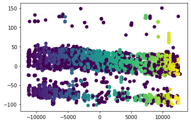

```python
pca = PCA(n_components=2)
pca_components = pca.fit_transform(X_all)

algorithm_types = ['auto', 'ball_tree', 'kd_tree', 'brute']

for a_type in algorithm_types:
        optics_cluster = OPTICS(min_samples=6,
                                     algorithm=a_type)
        cluster_labels = optics_cluster.fit_predict(pca_components)
        print('OPTICS with', a_type, 'algorithm and six components.')
        print("The silhoutte score of the OPTICS solution: {}".format(metrics.silhouette_score(pca_components, cluster_labels, metric='euclidean')))
        plt.scatter(pca_components[:,0], pca_components[:,1], c=cluster_labels)
        plt.show()
        print('\n')
```

[output not shown]

[output not shown]

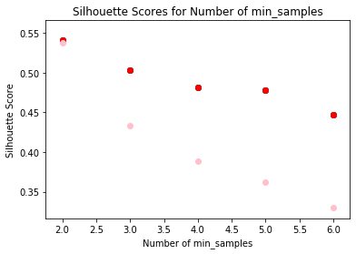

[output not shown]

```python
# With PCA components from features with greater than 0.01 correlation

pca = PCA(n_components=2)
pca_components = pca.fit_transform(X_50hd)
silhouettes_optics_pca = []
min_samples = [2, 3, 4, 5, 6]
dbs_optics_pca = []

# looping through cluster numbers to find the best cluster
silhouettes_optics_pca_auto = {} # silhoutte scores are keys, n_components are values
for n in min_samples:
        optics_cluster = OPTICS(min_samples=n, algorithm='auto')
        cluster_labels = optics_cluster.fit_predict(pca_components)
        silhouette = metrics.silhouette_score(pca_components, cluster_labels, metric='euclidean')
        silhouettes_optics_pca_auto[silhouette] = n
        db = metrics.davies_bouldin_score(pca_components, cluster_labels)
        dbs_optics_pca.append(db)

silhouettes_optics_pca_ball_tree = {} # silhoutte scores are keys, n_components are values
for n in min_samples:
        optics_cluster = OPTICS(min_samples=n, algorithm='ball_tree')
        cluster_labels = optics_cluster.fit_predict(pca_components)
        silhouette = metrics.silhouette_score(pca_components, cluster_labels, metric='euclidean')
        silhouettes_optics_pca_ball_tree[silhouette] = n
        db = metrics.davies_bouldin_score(pca_components, cluster_labels)
        dbs_optics_pca.append(db)

silhouettes_optics_pca_kd_tree = {} # silhoutte scores are keys, n_components are values
for n in min_samples:
        optics_cluster = OPTICS(min_samples=n, algorithm='kd_tree')
        cluster_labels = optics_cluster.fit_predict(pca_components)
        silhouette = metrics.silhouette_score(pca_components, cluster_labels, metric='euclidean')
        silhouettes_optics_pca_kd_tree[silhouette] = n
        db = metrics.davies_bouldin_score(pca_components, cluster_labels)
        dbs_optics_pca.append(db)

silhouettes_optics_pca_brute = {} # silhoutte scores are keys, n_components are values
for n in min_samples:
        optics_cluster = OPTICS(min_samples=n, algorithm='brute')
        cluster_labels = optics_cluster.fit_predict(pca_components)
        silhouette = metrics.silhouette_score(pca_components, cluster_labels, metric='euclidean')
        silhouettes_optics_pca_brute[silhouette] = n
        db = metrics.davies_bouldin_score(pca_components, cluster_labels)
        dbs_optics_pca.append(db)

# plotting the silhouette scores
plt.title('Silhouette Scores for Number of min_samples')
plt.scatter(list(silhouettes_optics_pca_auto.values()), list(silhouettes_optics_pca_auto.keys()), color='blue')
plt.scatter(list(silhouettes_optics_pca_ball_tree.values()), list(silhouettes_optics_pca_ball_tree.keys()), color='green')
plt.scatter(list(silhouettes_optics_pca_kd_tree.values()), list(silhouettes_optics_pca_kd_tree.keys()), color='red')
plt.scatter(list(silhouettes_optics_pca_brute.values()), list(silhouettes_optics_pca_brute.keys()), color='pink')
plt.xlabel('Number of min_samples')
plt.ylabel('Silhouette Score')
plt.show()


print('Best Silhouette score with auto algorithm is {} with {} min_samples. '.format(max(silhouettes_optics_pca_auto.keys()), silhouettes_optics_pca_auto[max(silhouettes_optics_pca_auto.keys())]))
print('Best Silhouette score with ball_tree algorithm is {} with {} min_samples. '.format(max(silhouettes_optics_pca_ball_tree.keys()), silhouettes_optics_pca_ball_tree[max(silhouettes_optics_pca_ball_tree.keys())]))
print('Best Silhouette score with kd_tree algorithm is {} with {} min_samples. '.format(max(silhouettes_optics_pca_kd_tree.keys()), silhouettes_optics_pca_kd_tree[max(silhouettes_optics_pca_kd_tree.keys())]))
print('Best Silhouette score with brute algorithm is {} with {} min_samples. '.format(max(silhouettes_optics_pca_brute.keys()), silhouettes_optics_pca_brute[max(silhouettes_optics_pca_brute.keys())]))
print('Best Davies Bouldin score: ', min(dbs_optics_pca))
```

```
OPTICS with auto algorithm and two min_samples.
The silhoutte score of the OPTICS solution: 0.5358350494460037
```

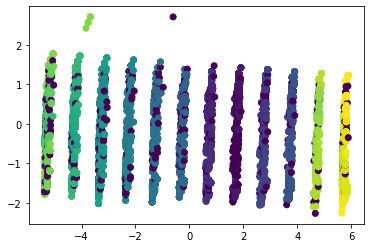

```python
pca = PCA(n_components=2)
pca_components = pca.fit_transform(X_50hd)

optics_cluster = OPTICS(min_samples=2,
                                     algorithm='auto')
cluster_labels = optics_cluster.fit_predict(pca_components)
print('OPTICS with auto algorithm and two min_samples.')
print("The silhoutte score of the OPTICS solution: {}".format(metrics.silhouette_score(pca_components, cluster_labels, metric='euclidean')))
plt.scatter(pca_components[:,0], pca_components[:,1], c=cluster_labels)
plt.show()
print('\n')
```

## Neural Networks

## RBM

```python
rbm = BernoulliRBM(n_components=64, learning_rate=0.1,
                            batch_size=10, random_state=9)
```

```python
# number of neurons in the encoding hidden layer
encoding_dim = 5
# input placeholder
input_data = Input(shape=(6,)) # 6 is the number of features/columns
# encoder is the encoded representation of the input
encoded = Dense(encoding_dim, activation ='relu')(input_data)
# decoder is the lossy reconstruction of the input
decoded = Dense(6, activation ='sigmoid')(encoded) # 6 again number of features and should match input_data


# this model maps an input to its reconstruction
autoencoder = Model(input_data, decoded)




# this model maps an input to its encoded representation
encoder = Model(input_data, encoded)
# model optimizer and loss
autoencoder = Model(input_data, decoded)

# loss function and optimizer
autoencoder.compile(optimizer='adadelta', loss='binary_crossentropy')

# train test split
x_train, x_test, = train_test_split(data, test_size=0.1, random_state=42)


# train the model
autoencoder.fit(x_train,
                x_train,
                epochs=50,
                batch_size=256,
                shuffle=True)

autoencoder.summary()

# predict after training
# note that we take them from the *test* set
encoded_data = encoder.predict(x_test)
```

[output not shown]

For your third capstone, you’ll complete an unsupervised learning project. You can choose your own research question or choose from one below.

Go out and find a dataset of interest. It could be one that helps you work on one of our recommended research questions, or any other dataset that addresses an unsupervised learning question of your own.

Explore the data. Get to know the data. Spend a lot of time going over its quirks and peccadilloes. You should understand how it was gathered, what's in it, and what the variables look like.

You should try several different approaches and really work to tune a variety of models before choosing what you consider to be the best performer.

Things to keep in mind: how do clustering and modeling compare? What are the advantages of each? Why would you want to use one over the other?

Be prepared to talk about:

Your end-user and the value your project provides to them.

Quantifiable results based on the research you’ve conducted. The visuals you chose and what they represent for your research. Next steps you'd take to expand on your work. A specified research question your model addresses. How you chose your model specification and what alternatives you compared it to. The practical uses of your model for an audience of interest. Any weak points or shortcomings of your model.